# DSA Assignment 2

### Anubhav Gupta IT 19124014

### Submitted to Dr. Laltendu Behera

Task: To analyse time complexity of 5 functions using asymptotic analysis

#### The 5 functions are chosen according to O(1), O(n), O(n<sup>2</sup>), O(logn), O(nlogn) :

Choice of Language is python for easy graphics utility

### Method followed for analysis

first I tried integrating c++ in jupyter, it worked but there was isses in graphing libraries so I switched to python as the assignment was language independent: Here I am employing libraries like **timeit** and **Random** for collecting time data and generating random inputs, for plotting I've used **Matpolib**  
There is a driving code having a for loop that uses random function to drive the function defined in the snippet, that loop generates two lists that act as data given to graphing snippet that plots the graph accordingly

**function 1** : Here we define a function with **O(1)** and we shall plot it's graph to expect a straight line parallel to X axis

#### analysing the situation

In the above case we've chosen a function that can be used to find the area of a square and clearly has time complexity as **O(1)**  
The scatter plot gives a better picture than the line chart and this can be clearly seen that there is a dense line in the center which is covered between two lines that can be seen as best and worst case scenarios, whereas the middle one can be seen representing the average case scenario, The several of random dots up high can be caused due to sysem noise and random delays in processor

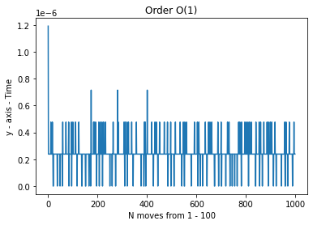

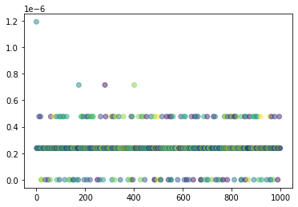

```python
import time
import matplotlib
import matplotlib.pyplot as plt
import numpy as np

time_ =[]
value = []

def area(n):
    r=n*n

for x in range(0,1000,1):
    t0=time.time()
    area(x)
    t1 = time.time() - t0
    value.append(x)
    time_.append(t1)


plt.plot(value,time_)
plt.xlabel('N moves from 1 - 100')
plt.ylabel('y - axis - Time')
plt.title('Order O(1)')
plt.show()

colors = np.random.rand(1000)
# area = (30 * 2)**2  # 0 to 15 point radii
plt.scatter(value, time_, c=colors, alpha=0.5)
plt.show()
```

**Function 2** : Here we define a function with **O(n)** and we shall plot it's graph to expect a linear growth

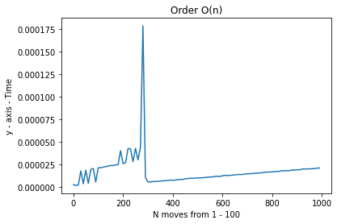

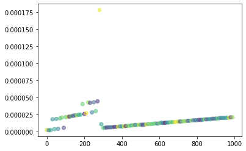

```python
import time
import matplotlib
import matplotlib.pyplot as plt
import numpy as np

time_ =[]
value = []

def fun(n):
    for i in range(n):
        a=1*1

for x in range(0,1000,10):
    t0=time.time()
    fun(x)
    t1 = time.time() - t0
    value.append(x)
    time_.append(t1)


plt.plot(value,time_)
plt.xlabel('N moves from 1 - 100')
plt.ylabel('y - axis - Time')
plt.title('Order O(n)')


plt.show()


colors = np.random.rand(100)
# area = (30 * 2)**2  # 0 to 15 point radii
plt.scatter(value, time_, c=colors, alpha=0.5)
plt.show()
```

**Function 3** : Here we define a function with **O(n<sup>2</sup>)** and we shall plot it's graph to expect a quadratic growth  
The program has two for loops and perform a primitive function and raises the time with time complexity with a quadratic rate the parabola clearly shows a quadratic growth in both line and scatter plots,

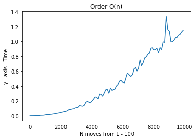

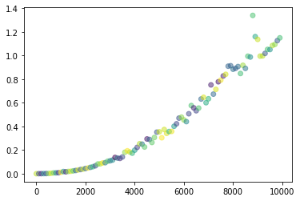

```python
import time
import matplotlib
import matplotlib.pyplot as plt
import numpy as np

time_ =[]
value = []

def fun(n):
    for i in range(n):
        for j in range(i):
            c=+1

for x in range(0,10000,100):
    t0=time.time()
    fun(x)
    t1 = time.time() - t0
    value.append(x)
    time_.append(t1)


plt.plot(value,time_)
plt.xlabel('N moves from 1 - 100')
plt.ylabel('y - axis - Time')
plt.title('Order O(n)')
plt.show()



colors = np.random.rand(100)
# area = (30 * 2)**2  # 0 to 15 point radii
plt.scatter(value, time_, c=colors, alpha=0.5)
plt.show()
```

**Function 4** : Here we define a function with **O(log(n))** and we shall plot it's graph to expect a lograthmic growth  
The program works on divide and conquer algorithm the famous binary search

the famous algorithm works on divide and conquer where we divide the array till we reach a part where the middle value is the value to be found  
the plot here shows a lot of peaks that distort the regular expected path of a lograthmic growth,these peaks might be due to encountering the worst cases

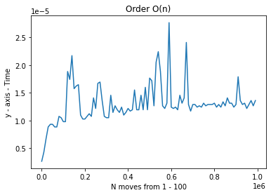

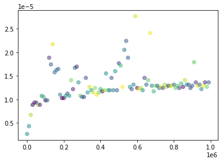

```python
import time
import matplotlib
import matplotlib.pyplot as plt
import numpy as np

time_ =[]
value = []

def binary_search(arr, x):
    low = 0
    high = len(arr) - 1
    mid = 0

    while low <= high:

        mid = (high + low) // 2

        # Check if x is present at mid
        if arr[mid] < x:
            low = mid + 1

        # If x is greater, ignore left half
        elif arr[mid] > x:
            high = mid - 1

        # If x is smaller, ignore right half
        else:
            return mid

    # If we reach here, then the element was not present
    return -1


# Test array
arr = []
# Function call


for x in range(0,1000000,10000):
    for y in range(0,x):
        arr.append(random.randint(0,1000))
    t0=time.time()
    result = binary_search(arr, x)
    t1 = time.time() - t0
    value.append(x)
    time_.append(t1)


plt.plot(value,time_)
plt.xlabel('N moves from 1 - 100')
plt.ylabel('y - axis - Time')
plt.title('Order O(n)')
plt.show()



colors = np.random.rand(100)
# area = (30 * 2)**2  # 0 to 15 point radii
plt.scatter(value, time_, c=colors, alpha=0.5)
plt.show()
```

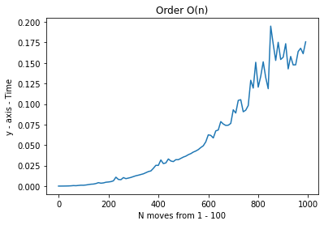

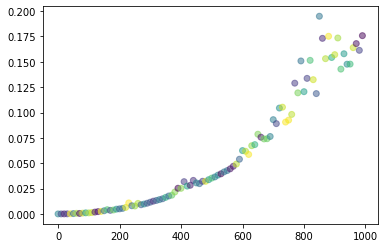

```python
import time
import matplotlib
import matplotlib.pyplot as plt
import numpy as np

time_ =[]
value = []

def mergeSort(arr):
    if len(arr) >1:
        mid = len(arr)//2 # Finding the mid of the array
        L = arr[:mid] # Dividing the array elements
        R = arr[mid:] # into 2 halves

        mergeSort(L) # Sorting the first half
        mergeSort(R) # Sorting the second half

        i = j = k = 0

        # Copy data to temp arrays L[] and R[]
        while i < len(L) and j < len(R):
            if L[i] < R[j]:
                arr[k] = L[i]
                i+= 1
            else:
                arr[k] = R[j]
                j+= 1
            k+= 1

        # Checking if any element was left
        while i < len(L):
            arr[k] = L[i]
            i+= 1
            k+= 1

        while j < len(R):
            arr[k] = R[j]
            j+= 1
            k+= 1


# Test array
arr = []
# Function call


for x in range(0,1000,10):
    for y in range(0,x):
        arr.append(random.randint(0,1000))
    t0=time.time()
    result = mergeSort(arr)
    t1 = time.time() - t0
    value.append(x)
    time_.append(t1)


plt.plot(value,time_)
plt.xlabel('N moves from 1 - 100')
plt.ylabel('y - axis - Time')
plt.title('Order O(n)')
plt.show()



colors = np.random.rand(100)
# area = (30 * 2)**2  # 0 to 15 point radii
plt.scatter(value, time_, c=colors, alpha=0.5)
plt.show()
```